# Homework 3

Linguistic Data: Quantitative Analysis and Visualisation

Deadline: 9 February, 12:00

The solutions should be submitted via GitHub.

## Part 1. A preliminary training

*Do not use R (RStudio) to solve problems in Part 1. Answers won’t be evaluated.* ### Problem 1 Look at the following histogram and answer the questions.

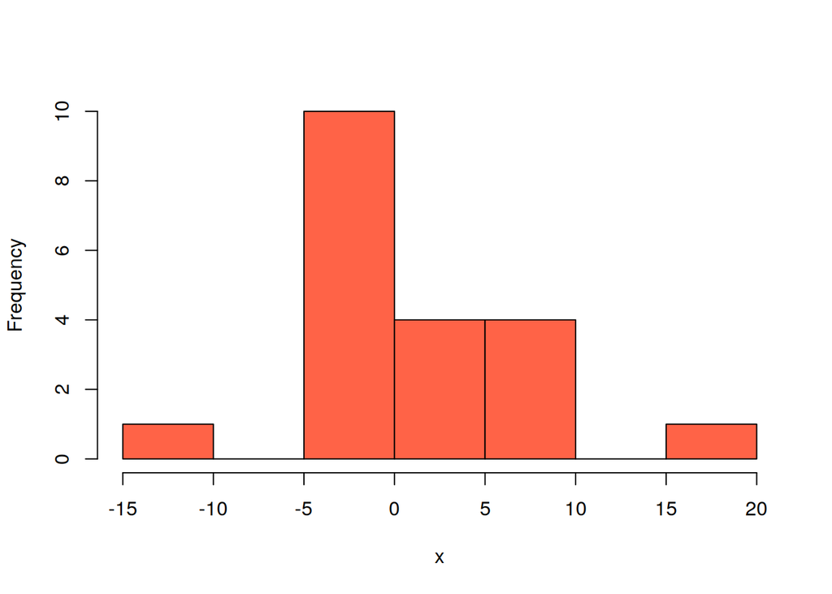

a. What is the proportion of values in the sample that exceed $5$? Explain your answer.

On the graph above we can see that values between $-15$ and $-10$ have the frequency of $1$, values between $-5$ and $0$ have the frequency of $10$, and values between $0$ and $5$ have the frequency of $4$. Meanwhile, values between $5$ and $10$ have the frequncy of $4$ and values between $15$ and $20$ have the frequency of $1$.
Total values:
$$1 + 10 + 4 + 4 + 1 = 20$$
Values that exceed five:
$$1 + 4 = 5$$
Thus, the proportion of the sample that exceeds $5$ equals to $5/20=1/4$.

2. Indicate the interval where the median of this sample can lie. Explain your answer.

The interval between $-5$ and $0$ seems like the interval where the median should lie. The values in this interval are the most likely ones in this sample ($10/20$). By definition the median should divide the sample in two equal halves. Seeing that this interval lies near the middle, and also taking into account that the histogram is slightly skewered to the left, we can suppose that this is where the median lies.

3. How the histogram will change if we add an element $7$ to the sample? Explain your answer.

The interval between $5$ and $10$ will have an additional element, so its absolute frequency will rise by one and will be equal to $5$.

### Problem 2

1. Look at the histograms of two samples. They illustrate the distribution of normalized average reaction time to frequent words (in ms) in two groups of people.

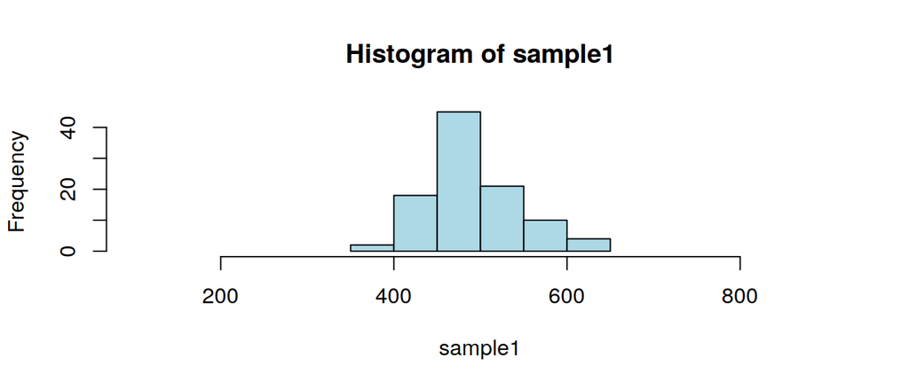

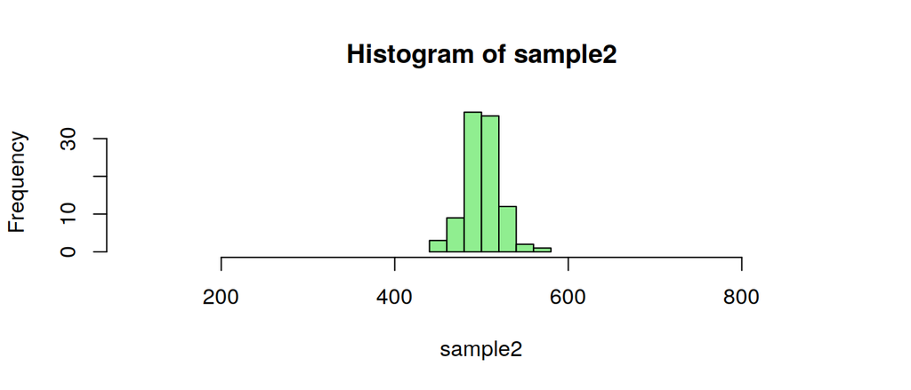

   Which of the samples has a larger variance? Explain your answer.

2. Look at the histograms of two samples.

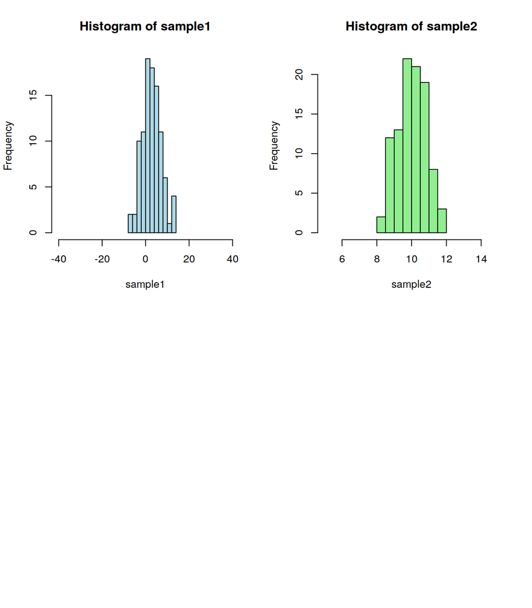

   Which of the samples has a larger variance? Explain your answer.

The fact that the first sample has higher variance is obvious because the interval of values is much bigger. We can see that the difference between min an max value is approximately 20 on the first sample and about 4 on the second.

## Part 2

*Do not use R (RStudio) to solve problems in Part 2. Answers for problem 3 will be evaluated. Please paste YES or NO into (empty) code blocks and explain you answer below the block.*

### Problem 3

Below is the histogram of the number of mistakes students made while writing an examination essay in English. Look at the histogram and answer the questions.

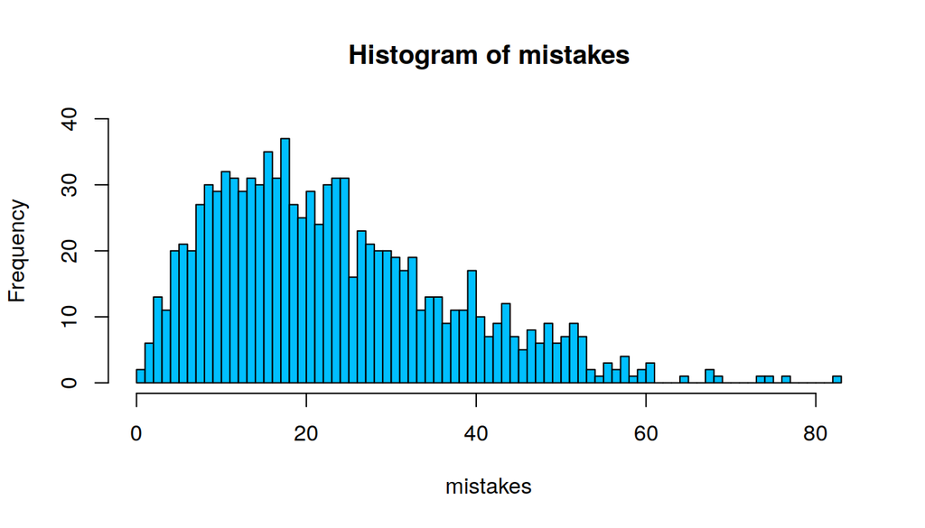

### 3.1

Is it true that $50$% students made more than $35$ mistakes?

```
NO
```

Explain your answer below: It’s clear that the majority of observations lies the left of the middle of the graph, certainly below 50.

### 3.2

Is it true that most students made no more than $10$ mistakes?

```
NO
```

Explain your answer below: It seems that most observations lie between about 10 and 25. So it can’t be said that most student made 10 or less mistakes.

### 3.3

Which of the following values is closer to be the median of `mistakes`: $10$, $20$, $30$, $40$?

```
20
```

Explain your answer below: We can see that a significant part of observations is concentrated to the left of 20. Values to the right are more spread out, but it seems to be about the same in total as the left side.

### Problem 4. Exact binomial test

The null hypothesis is that $p=0$ (i.e. no success is possible). In a dataset, there is only one success out of 1 000 000 observations. Will you reject the null hypothesis?

[output not shown]

Explain your answer below: Alternative hypothesis is that p > 0. To reject the null hypothesis p-value must exceed $\alpha$. In our dataset p-value equals to 0 (the possibility that there will be 1 or more successes) which is lower that any $\alpha$. Thus, the null hypothesis is rejected.

## Part 3

*Use R (RStudio) to solve problems in Part 3. Your answers will be evaluated. Please paste R code into R code blocks and explain you answer below the block, if needed.*

### Problem 5

Here is a sample of respondents’ age:

$44$, $50$, $42$, $64$, $66$, $42$, $72$, $56$, $72$, $54$, $46$, $48$, $48$, $52$, $50$, $66$, $84$.

### 5.1

Arrange them in a vector and call it `age`.

```r
age <- c(44, 50, 42, 64, 66, 42, 72, 56, 72, 54, 46, 48, 48, 52, 50, 66, 84)
age
```

```
##  [1] 44 50 42 64 66 42 72 56 72 54 46 48 48 52 50 66 84
```

### 5.2

Examine the type of `age` variable (numeric, character, etc).

```r
class(age)
```

```
## [1] "numeric"
```

### 5.3

Plot the histogram of the vector `age` with $5$ bins. Change its color to any you want. (Use either R basic or ggplot2 style for plotting.)

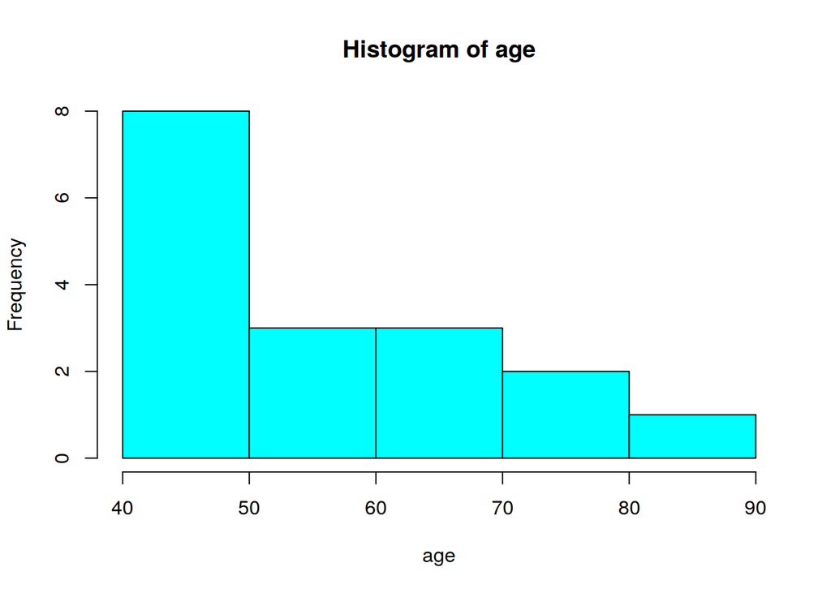

```r
hist(age, breaks = 4, col = 'cyan')
```

### Problem 6

Here is a series of words:  
*pie, bar, bar, pie, pie, bar, bar, chart*.

### 6.1

Arrange elements above in a vector and call it `words`

```r
words <- c('pie', 'bar', 'bar', 'pie', 'pie', 'bar', 'bar', 'chart')
words
```

```
## [1] "pie"   "bar"   "bar"   "pie"   "pie"   "bar"   "bar"   "chart"
```

### 6.2

Calculate the relative frequences of values in `words` measured in percent.

```r
table(words)/sum(table(words))
```

```
## words
##   bar chart   pie
## 0.500 0.125 0.375
```

## Problem 7. Position of verbs in verses

The dataset [“The last words in verses”](https://raw.githubusercontent.com/LingData2019/LingData2020/master/data/poetry_last_in_lines.csv) is based on texts written in the 1820s and 1920s (Corpus of Russian Poetry of the Russian National Corpus). Authors collected only one line per author to keep observations as independent from each other as possible.

Variables:  
- Decade — decade of creation: 1820s, 1920s.  
- RhymedNwords — the number of words in the rhyming position (usually one word, but there are two words in cases such as *вина бы* ‘I would like to get) wine’ (which is rhymed with *жабы* ‘toad’, see http://russian-poetry.ru/Poem.php?PoemId=18261)).  
- RhymedNsyl — the number of syllables in the rhyming position.  
- UPoS — part of speech of the last word. - LineText — a sampled verse.  
- Author — the author of the text.

Can we decide that in verses written in 1920s, verbs in the rhyming position are used differently (more often or less often) than expected for verbs in general?

### 7.1 State hypothesis

What is your null hypothesis $H_0$ and what is the alternative hypothesis $H_1$?

```
H0: The probability of a verb in the rhyming position is the same as the probability of
a verb in general which is 0.17, so p(V) = 0.17
H1: The alternative hypothesis is that the probability is different, so p(V) != 0.17
```

### 7.2

Read the dataset [“The last words in verses”](https://raw.githubusercontent.com/LingData2019/LingData2020/master/data/poetry_last_in_lines.csv). Filter out the relevant observations from 1920s, calculate the number of verbs observed in the sample, and the sample size.

```r
library(readr)
library(tidyverse)
df <- read_delim("https://raw.githubusercontent.com/LingData2019/LingData2020/master/data/poetry_last_in_lines.csv",  "\t")
df_1920s <- df %>%
  filter(Decade == '1920s')
sample_size <- nrow(df_1920s)
verb_num <- df_1920s %>%
  filter(UPoS == 'VERB') %>%
  nrow()
paste('Sample size:', sample_size)
```

```
## [1] "Sample size: 277"
```

```r
paste('Number of verbs:', verb_num)
```

```
## [1] "Number of verbs: 39"
```

### 7.3

Use an exact binomial test to calculate p-value.

```r
binom.test(verb_num, sample_size, alternative = 'two.sided', conf.level = 0.95, p = 0.17)
```

```
##
##  Exact binomial test
##
## data:  verb_num and sample_size
## number of successes = 39, number of trials = 277, p-value = 0.2297
## alternative hypothesis: true probability of success is not equal to 0.17
## 95 percent confidence interval:
##  0.1020719 0.1874081
## sample estimates:
## probability of success
##              0.1407942
```

### 7.4 Interpret results

Give your interpretation of obtained p-value. Answer the initial question: Can we decide that in verses written in 1920s, verbs are used in the rhyming position more often or less often than expected?

```
Since confidence level was set at 0.95, the value of alpha equals to 0.05. The obtained p-value (0.2297) is considerably larger than alpha, so we can't reject the null hypothesis. Consequently, we can conclude that verbs are not used more or less frequently in the rhyming position.
```

### 7.5

*(A bonus problem, extra points in evaluation)*. Repeat 2.3 for verses written in the 1820s.

```r
df_1820s <- df %>%
  filter(Decade == '1820s')
sample_size <- nrow(df_1820s)
verb_num <- df_1820s %>%
  filter(UPoS == 'VERB') %>%
  nrow()
paste('Sample size:', sample_size)
```

```
## [1] "Sample size: 87"
```

```r
paste('Number of verbs:', verb_num)
```

```
## [1] "Number of verbs: 15"
```

```r
binom.test(verb_num, sample_size, alternative = 'two.sided', conf.level = 0.95, p = 0.17)
```

```
##
##  Exact binomial test
##
## data:  verb_num and sample_size
## number of successes = 15, number of trials = 87, p-value = 0.8873
## alternative hypothesis: true probability of success is not equal to 0.17
## 95 percent confidence interval:
##  0.09983452 0.26837791
## sample estimates:
## probability of success
##              0.1724138
```

Write down your general conlusions about data provided for both 1920s and 1820s data.

```
Here we can see that p-value is even higher, so we can't reject the null hypothesis either. Despite the different proportions verb distribution doesn't seem to be affected by the rhyming position.
```

### Problem 8. One-sample t-test

Using Icelandic data on vowel duration from seminar [Link](https://raw.githubusercontent.com/LingData2019/LingData2020/master/data/icelandic.csv) test the null hypothesis that the population mean of vowel duration in speaker `shg05` equals 73 (ms). To perform a one-sample t-test, you can use the following example of R code:

```
t.test(sample, mu = 7725) # mu is a population mean
```

```r
df <- read_csv("https://raw.githubusercontent.com/LingData2019/LingData2020/master/data/icelandic.csv")
df_shg05 <- df %>%
  filter(speaker == 'shg05')
```

### 8.1

Write down a two-tailed alternative hypothesis.

```
H1: The population mean of vowel duration for speaker shg05 is not equal to 73.
```

### 8.2

Perform a one-sample t-test.

```r
t.test(df_shg05$vowel.dur, mu = 73)
```

```
##
##  One Sample t-test
##
## data:  df_shg05$vowel.dur
## t = -1.9602, df = 159, p-value = 0.05172
## alternative hypothesis: true mean is not equal to 73
## 95 percent confidence interval:
##  67.18817 73.02188
## sample estimates:
## mean of x
##  70.10502
```

### 8.3

Interpret results.

```
The obtained p-value is larger than alpha (0.05). This means that the null hypothesis cannot be rejected. In other words, with confidence of 95% we can say the mean vowel duration for speaker shg05 is equal to 73.
```

#### Supplementary reading

Use of exact binomial test in lingiistic research:

- Gries, Stefan Th. “Phonological similarity in multi-word units.” Cognitive Linguistics 22.3 (2011): 491-510. [Link](http://citeseerx.ist.psu.edu/viewdoc/download?doi=10.1.1.186.7412&rep=rep1&type=pdf)  
  Stefan Gries proves that alliteration is observed in multi-word expressions more often than in general.
- Harald Bayen (2008: 51-52) evaluates the probability of observing exactly one occurrence of the word *hare* in the corpus sample of 1 mln words given its estimated frequency of 8.23 words per million according to the SELEX frequency database.

On measures of central tendency:

- Levshina 2015, Chapter 3 (p. 48); Gries 2009, Chapter 1.3 (p. 116).

On t-test:

- Gries 2009, Chapter 3 (p. 198).